# Datos de Nacimiento

Jorge de la Vega

5 de agosto de 2018

## Ejemplo 1: Datos de nacimiento

Los siguientes datos corresponden a 427,323 registros con 13 variables de nacimientos de bebés en los Estados Unidos durante 2006[^1]

```r
library(lattice)
library(ggplot2)
library(nutshell)     #paquete que contiene los datos
data(births2006.smpl) #datos de nacimiento
str(births2006.smpl) #estructura de los datos
```

```
'data.frame':   427323 obs. of  13 variables:
 $ DOB_MM   : int  9 2 2 10 7 3 5 4 10 4 ...
 $ DOB_WK   : int  1 6 2 5 7 3 2 7 3 4 ...
 $ MAGER    : int  25 28 18 21 25 28 33 31 18 24 ...
 $ TBO_REC  : int  2 2 2 2 1 3 2 3 1 2 ...
 $ WTGAIN   : int  NA 26 25 6 36 35 26 25 46 43 ...
 $ SEX      : Factor w/ 2 levels "F","M": 1 2 1 2 2 2 2 1 1 2 ...
 $ APGAR5   : int  NA 9 9 9 10 8 9 9 9 9 ...
 $ DMEDUC   : Factor w/ 18 levels "1 year of college",..: 18 4 18 18 6 18 18 4 18 6 ...
 $ UPREVIS  : int  10 10 14 22 15 18 10 19 15 13 ...
 $ ESTGEST  : int  99 37 38 38 40 39 38 38 40 40 ...
 $ DMETH_REC: Factor w/ 3 levels "C-section","Unknown",..: 3 3 3 3 3 3 1 1 1 3 ...
 $ DPLURAL  : Factor w/ 5 levels "1 Single","2 Twin",..: 1 1 1 1 1 1 1 1 1 1 ...
 $ DBWT     : int  3800 3625 3650 3045 3827 3090 3430 3204 3227 3459 ...
```

- *DOB_MM*: mes de la fecha de nacimiento
- *DOB_WK*: semana de la fecha de nacimiento
- *MAGER:*: edad de la madre
- *TBO_REC*: orden de nacimiento total
- *WTGAIN*: peso ganado de la madre
- *SEX*: sexo del bebé
- *APGAR5*: score Apgar
- *DMEDUC*: Nivel educativo de la madre
- *UPREVIS*: Número de visitas prenatales
- *ESTGEST*: semanas de gestación estimadas
- *DMETH_REC*: Método de nacimiento
- *DPLURAL*: Nacimientos múltiples (único, gemelos, triátes, etc.)
- *DBWTH*: Peso al nacer (en gramos)

Para realizar nuestro análisis, podemos separar los datos cuantitativos de los categóricos y éstos últimos utilizarlos como *etiquetas* para analizar la información por grupos. La matriz $X$ se conforma con todas las variables, convirtiendo a factores las variables categóricas.

### Algunas preguntas relevantes sobre los datos

Todo análisis comienza intentando responder algunas preguntas básicas que podamos responder obteniendo algunas estadísticas descriptivas de la información. Por ejemplo:

- ¿Cuál es el peso promedio de los bebés al nacimiento?
- ¿Hay alguna relación entre la edad de la madre o su peso y el peso de los bebés, o los nacimientos múltiples?
- ¿Hay alguna relación entre la edad de la madre y su nivel de escolaridad?
- ¿cuál es el periodo promedio de gestación y cuál es su desviación estándar?
- ¿Cómo se distribuye el número de nacimientos por mes? ¿por día de la semana?
- ¿Hay alguna relación entre la edad de la madre o su edad y el score Apgar del bebé?
- ¿Se puede predecir el peso del bebé de características como el periodo estimado de gestación y la ganancia en peso de la madre?
- ¿Podemos identificar nacimientos que llevan a un score APGAR bajo?

En las siguientes láminas se responderán algunas de estas preguntas.

### Peso promedio de los bebés al nacimiento.

Podemos simplemente analizar el peso promedio de los bebés a través de las estadísticas usuales:

```r
summary(births2006.smpl$DBWT/1000)
```

```
##    Min. 1st Qu.  Median    Mean 3rd Qu.    Max.    NA's
##   0.227   2.972   3.310   3.265   3.629   8.165     434
```

En los datos podemos ver que algunos casos (434) no tienen información del peso. El peso promedio de los bebés al nacimiento es de 3.265 y su desviación estándar es 0.595.

Podemos obtener más información sobre el peso:

- Podemos obtener la distribución de los pesos
- distribución del peso por género del bebé
- distribución del peso del bebé por nacimientos múltiples

### Histogramas

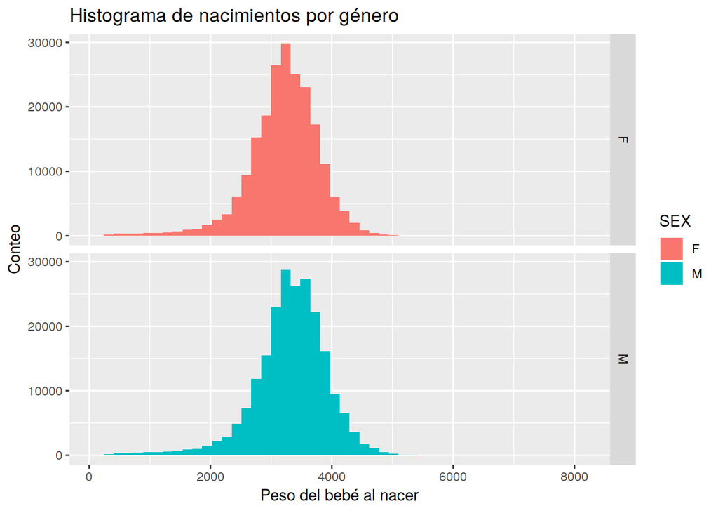

```r
ggplot(data=births2006.smpl,aes(DBWT,geom="density",fill=SEX)) +
geom_histogram(bins= 50) +
facet_grid(SEX~.) +
labs(title="Histograma de nacimientos por género",
      y = "Conteo",
      x = "Peso del bebé al nacer")
```

### Boxplots

Otra versión visual son los boxplots para comparar poblaciones:

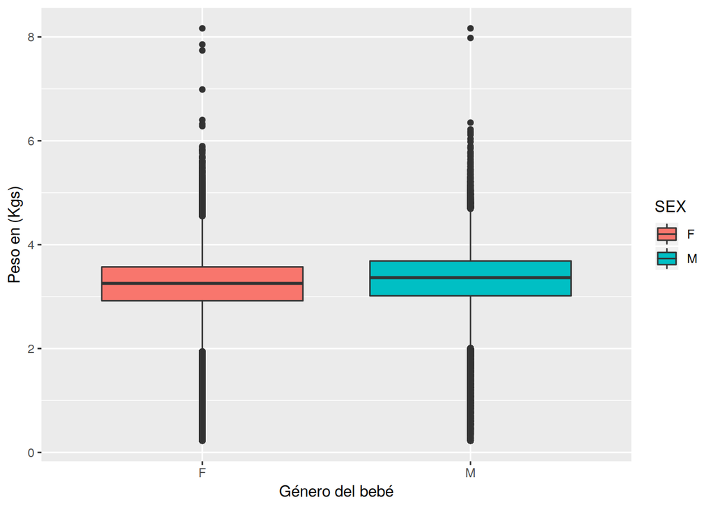

```r
ggplot(data=births2006.smpl,aes(x=SEX,y=DBWT/1000,fill=SEX)) +
geom_boxplot() +
labs(y = "Peso en (Kgs)", x = "Género del bebé")
```

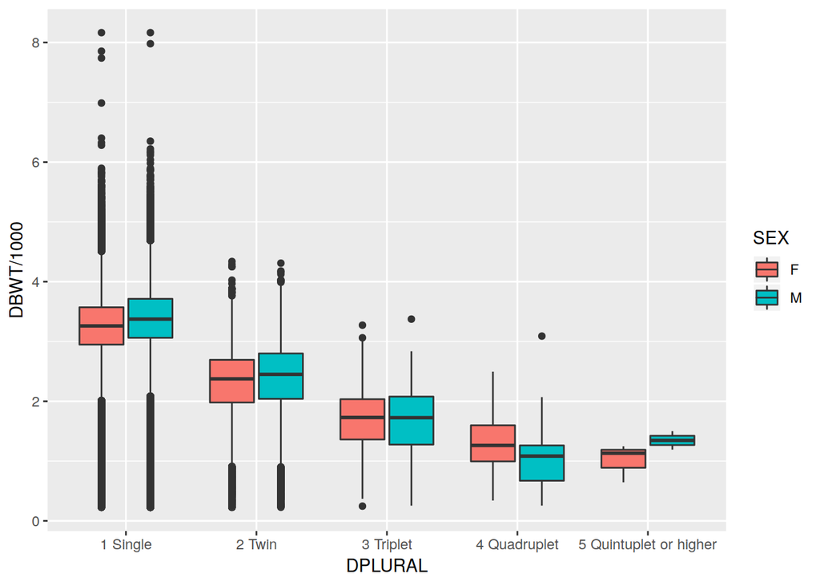

```r
ggplot(data=births2006.smpl,aes(x=DPLURAL,y=DBWT/1000,fill=SEX)) +
geom_boxplot()
```

### Nacimientos por día de la semana

La codificación comienza con domingo (1).

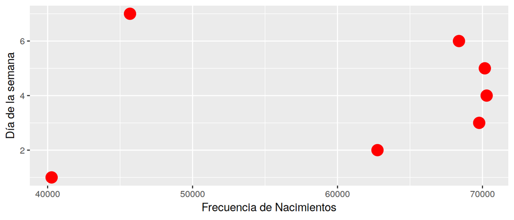

```r
suppressMessages(library(dplyr))
births2006.smpl %>%
  group_by(DOB_WK) %>%
  summarize(Numero = n()) %>%
  ggplot(aes(x = DOB_WK, y = Numero)) +
  geom_point(color="red", fill="red4", size=5) +
  labs(y = "Frecuencia de Nacimientos", x = "Día de la semana") +
  coord_flip()
```

### Por nacimientos múltiples

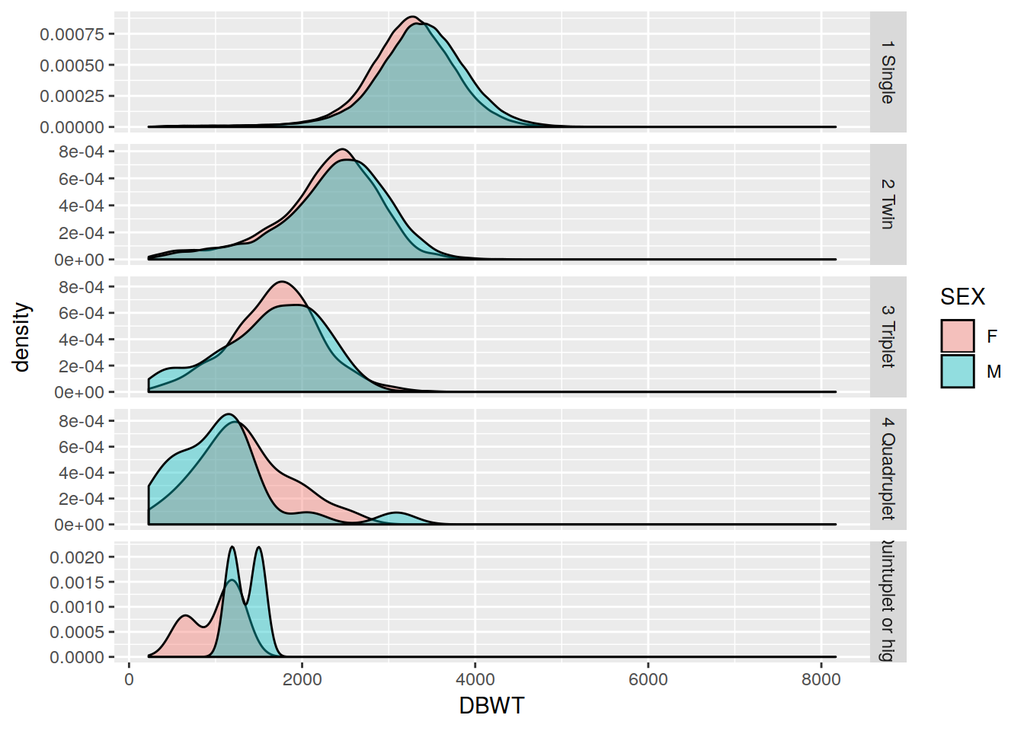

```r
ggplot(data=births2006.smpl,aes(DBWT,fill=SEX)) +
geom_density(alpha = 0.4) +
facet_grid(DPLURAL~.,scales="free")
```

```r
a <- births2006.smpl %>%
      select(MAGER,APGAR5,SEX, DBWT)
ggplot(data=a, aes(x=MAGER, y=DBWT, col=SEX, size=APGAR5)) +
  geom_point(alpha=0.3)
```

[output not shown]